# R Notebook - Analyze weather data

# 1 Load library

```r
library(tidyverse)
library(janitor)
```

Hourly Weather data downloaded from http://www.frontierweather.com/historicaldatasubscribers_hourly.html

Daily Weather data downloaded from http://www.frontierweather.com/weatherdatastore.html

# 2 Daily weather data

## 2.1 Read the Houston daily weather data

```r
houston_weather <- read_delim("weather_data/KIAH_daily.txt", delim = ",")
```

- Find out what these columns mean.
  - Site4 : Name of the site
  - Date : Date when the data was collected
  - Source : Name of their instrument
  - Max Temp : Maximum temperature of the day
  - Min Temp : Minimum temperature of the day
  - Avg Temp : Average temperature (Max + Min)/2
  - HDDs : Heating degree day (Temps below 65) https://w1.weather.gov/glossary/index.php?letter=h
  - CDDs : Cooling degree day (Temps above 65) - A form of degree day used to estimate energy requirements for air conditioning or refrigeration. For example, if a location experiences a mean temperature of 75°F on a certain day, there were 10 CDD (Cooling Degree Days) that day because 75 - 65 = 10.) https://w1.weather.gov/glossary/index.php?letter=c
  - Precipitation Water Equiv : Rain in inches
  - Snowfall : Amount of snowfall since 24 hours (https://www.weather.gov/gsp/snow)
  - Snow/Ice Depth : The depth of the new and old snow remaining on the ground at observation time (https://www.weather.gov/gsp/snow)

### 2.1.1 Find out more about this function

```r
??read_delim
```

## 2.2 “Format” the data

```r
houston_weather_df <- houston_weather %>%
  mutate(Date=as.Date(Date,format='%m/%d/%Y')) %>%
  separate(Date,c("year","month","day")) %>%
  janitor::clean_names()
```

## 2.3 Read Chicago daily weather data

```r
chicago_weather <- read_csv("weather_data/KORD_daily.txt")
```

Notice we have used different function but without explicitly mentioning delimiter.

## 2.4 “Format” Chicago weather

```r
chicago_weather_df <- chicago_weather %>%
  mutate(Date=as.Date(Date,format='%m/%d/%Y')) %>%
  separate(Date,c("year","month","day")) %>%
  janitor::clean_names()
```

## 2.5 Get Seattle weather data and format

```r
seattle_weather_df <- read_csv("weather_data/KSEA_daily.txt")  %>%
  mutate(Date = as.Date(Date, format='%m/%d/%Y')) %>%
  separate(Date, c("year","month","day")) %>%
  janitor::clean_names()
```

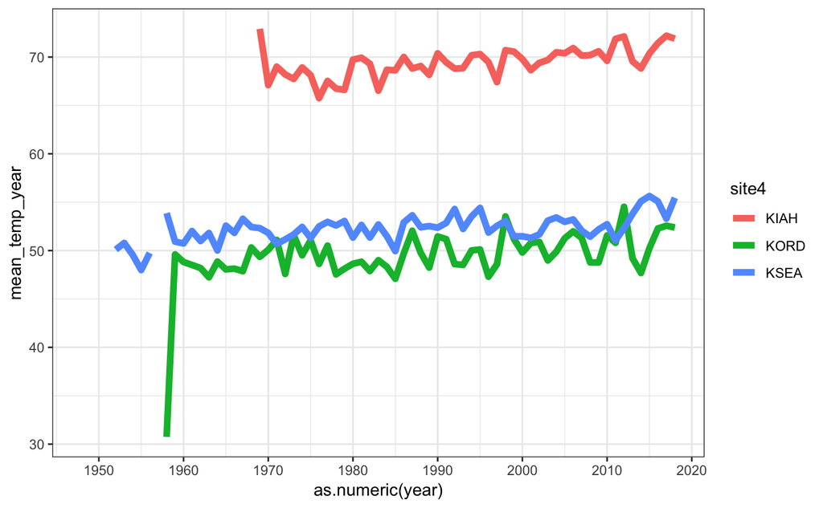

```r
houston_weather_df %>%
  bind_rows(., chicago_weather_df, seattle_weather_df) %>%
  group_by(site4, year) %>%
  summarise(mean_temp_year=mean(avg_temp)) %>%
  ungroup() %>%
  ggplot(.,aes(x = as.numeric(year), y = mean_temp_year, color = site4)) +
  geom_line(lwd = 2) +
  theme(axis.text.x = element_text(angle = 90, hjust = 1)) +
  scale_x_continuous(breaks = scales::pretty_breaks(n = 10)) +
  theme_bw()
```

Fix the x axis label and the legend??

## 2.7 Plot Histogram

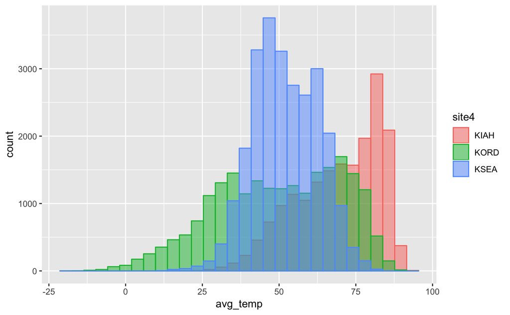

```r
houston_weather_df %>%
  bind_rows(., chicago_weather_df, seattle_weather_df) %>%
  ggplot(., aes(x=avg_temp, fill=site4, color=site4)) +
  geom_histogram(position="identity",  alpha = 0.5)
```

```r
  geom_histogram(position="identity")
```

```
geom_bar: na.rm = FALSE
stat_bin: binwidth = NULL, bins = NULL, na.rm = FALSE, pad = FALSE
position_identity
```

## 2.8 Plot Empirical Cumulative Distribution Function

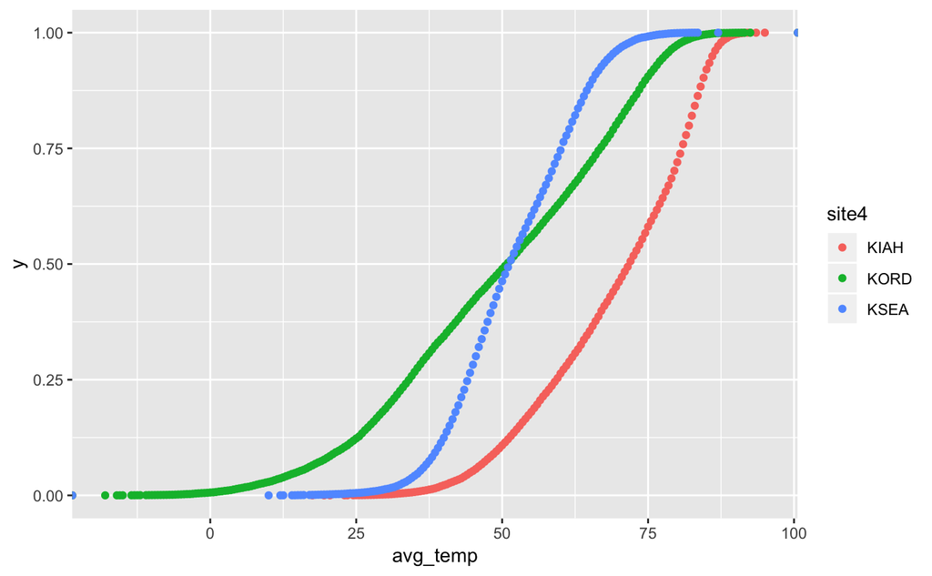

```r
houston_weather_df %>%
  bind_rows(., chicago_weather_df, seattle_weather_df) %>%
  ggplot(.,aes(avg_temp, color = site4)) +
  stat_ecdf(geom = "point")
```

A CDF is a function such as y=f(x) where y is the probability of the number x, or any lower number, being chosen at random from that distribution.

source: https://www.che.utah.edu/~tony/course/material/Statistics/18_rv_pdf_cdf.php

Here we are talking about ECDF “Empirical” CDF. This means this is not a representation of the entire set (or theoretical distribution) but what was observed and hence the word “empirical”.

## 2.9 Stem and leaf plot

```r
stem(houston_weather_df$max_temp)
```

```
  The decimal point is 1 digit(s) to the right of the |

   2 | 788889
   3 | 0011112223333333344444444
   3 | 5555666666666677777777777777888888888888999999999999999
   4 | 00000000000000000001111111111111111111111222222222222222222222222222+74
   4 | 55555555555555555555555555555555555555555555555555555556666666666666+210
   5 | 00000000000000000000000000000000000000000000000000000000000000000000+395
   5 | 55555555555555555555555555555555555555555555555555555555555555555555+632
   6 | 00000000000000000000000000000000000000000000000000000000000000000000+850
   6 | 55555555555555555555555555555555555555555555555555555555555555555555+1193
   7 | 00000000000000000000000000000000000000000000000000000000000000000000+1615
   7 | 55555555555555555555555555555555555555555555555555555555555555555555+2158
   8 | 00000000000000000000000000000000000000000000000000000000000000000000+2383
   8 | 55555555555555555555555555555555555555555555555555555555555555555555+2507
   9 | 00000000000000000000000000000000000000000000000000000000000000000000+3016
   9 | 55555555555555555555555555555555555555555555555555555555555555555555+1743
  10 | 00000000000000000000000000000000000000000000000000000000000000000000+167
  10 | 55555566777777899
```

It can be informative but compared to histogram or ecdf plot, it can be hard to read.

## 2.10 See the spread of the temperature by month

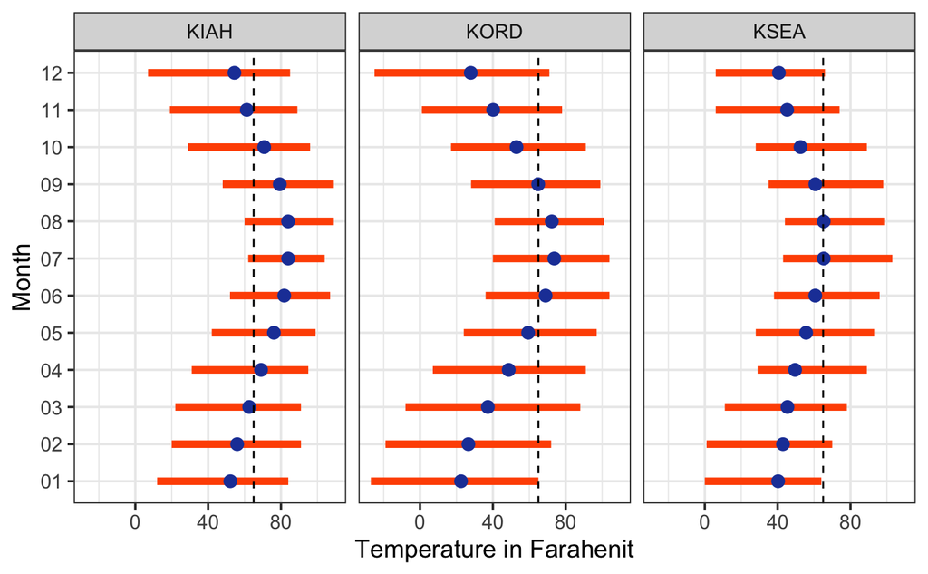

```r
houston_weather_df %>%
  bind_rows(chicago_weather_df, seattle_weather_df) %>%
  group_by(site4,month) %>%
  summarise(max = max(max_temp,na.rm = T),
            min = min(min_temp, na.rm = T),
            mean = mean(avg_temp, na.rm = T)) %>%
  ungroup() %>%
  ggplot(., aes(x = month, y = mean)) +
  geom_linerange(aes( ymin = min, ymax = max), lwd = 2, color = "#FF5400") +
  geom_point(size = 3, color = "#2142A6") +
  coord_flip() +
  theme_bw(base_size = 14) +
  geom_hline(yintercept = 65, linetype = "dashed") +
  xlab("Month") +
  ylab("Temperature in Farahenit") +
  facet_grid(.~site4)
```

# 3 Percent drop as compare to previous month.

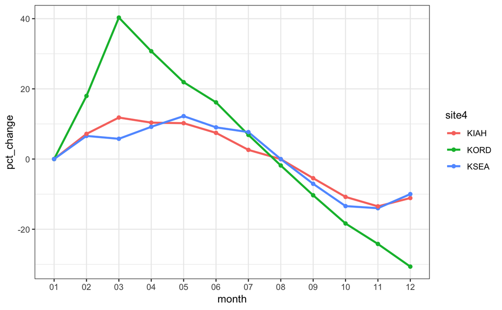

```r
houston_weather_df %>%
  bind_rows(chicago_weather_df) %>%
  bind_rows(seattle_weather_df) %>%
  group_by(site4, month) %>%
  summarise(mean_avg_temp = mean(avg_temp,na.rm = T)) %>%
  mutate(pct_change = (mean_avg_temp / lag(mean_avg_temp) - 1) * 100) %>%
  mutate(pct_change = case_when(
    is.na(pct_change) ~ 0,
    TRUE ~ as.numeric(pct_change)
  )) %>%
  arrange(pct_change) %>%
  ggplot(.,aes(x = month, y = pct_change, color = site4)) +
  geom_line(aes(group = site4), size = 1)+
  geom_point() +
  theme_bw()
```

## 3.1 Where does it rain the most?

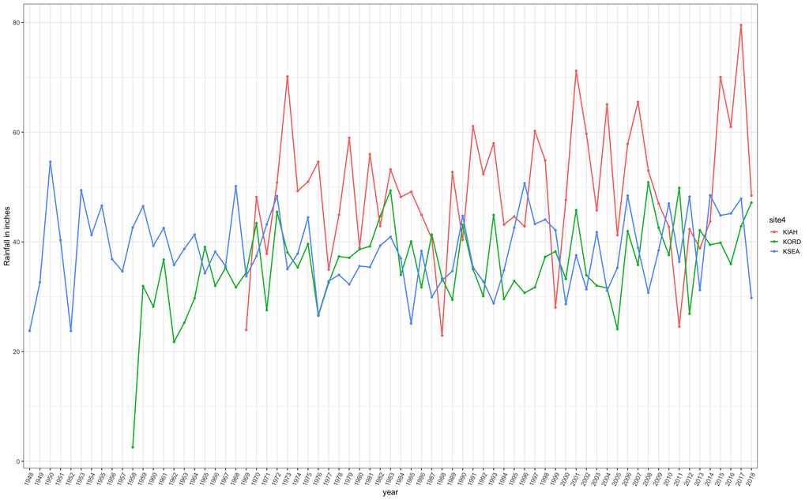

```r
houston_weather_df %>%
  bind_rows(chicago_weather_df, seattle_weather_df) %>%
  group_by(site4,year) %>%
  summarise(sum = sum(precipitation_water_equiv, na.rm = T)) %>%
  ungroup() %>%
  ggplot(., aes(x = year, y = sum, color = site4) ) +
  geom_point() +
  geom_line(aes(group = site4), size = 1)+
  theme_bw(base_size = 14) +
  theme(axis.text.x = element_text(angle = 65, hjust = 1)) +
  ylab("Rainfall in inches")
```

This graph shows total rainfall in inches over the years.

# 4 Average rainfall with the circles showing the maximum recorded rainfall for single day

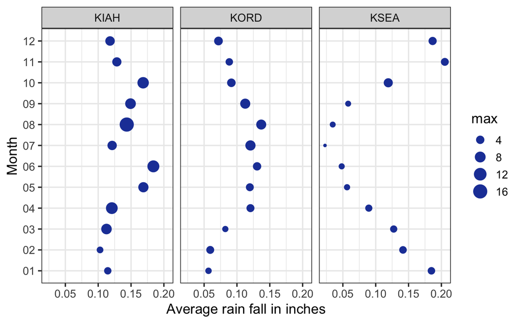

```r
houston_weather_df %>%
  bind_rows(chicago_weather_df, seattle_weather_df) %>%
  group_by(site4,month) %>%
  summarise(max = max(precipitation_water_equiv,na.rm = T),
            mean = mean(precipitation_water_equiv, na.rm = T)) %>%
  ungroup() %>%
  ggplot(. ) +
  geom_point(aes(x = month, y = mean,size = max), color = "#2142A6") +
  coord_flip() +
  theme_bw(base_size = 14) +
  xlab("Month") +
  ylab("Average rain fall in inches") +
  facet_wrap(.~site4)
```

# 5 Hourly weather data

## 5.1 Read Houston hourly weather data

```r
houston_weather_hourly <- read_csv("weather_data/KIAH.txt") %>%
  mutate(date=as.Date(Date,format='%m/%d/%Y')) %>%
  separate(date,c("year","month","day")) %>%
  janitor::clean_names()
```

[output not shown]

## 5.2 Read Chicago Hourly weather data

```r
chicago_weather_hourly <- read_csv("weather_data/KORD.txt") %>%
  mutate(date = as.Date(Date, format = '%m/%d/%Y')) %>%
  separate(date, c("year","month","day")) %>%
  janitor::clean_names()
```

[output not shown]

## 5.3 Add Seattle hourly weather data

```r
seattle_weather_hourly <- read_csv("weather_data/KSEA.txt") %>%
  mutate(date=as.Date(Date, format = '%m/%d/%Y')) %>%
  separate(date, c("year", "month", "day")) %>%
  janitor::clean_names()
```

[output not shown]

## 5.4 Is Seattle really cloudy as compare to Chicago and Houston?

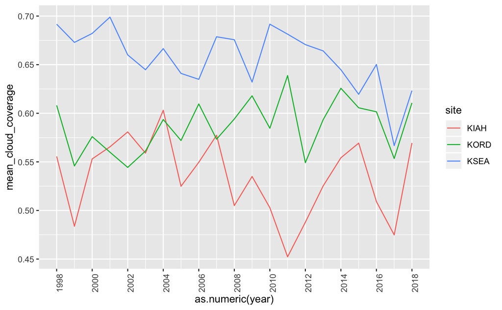

```r
houston_weather_hourly %>%
  bind_rows(., chicago_weather_hourly,seattle_weather_hourly ) %>%
  mutate(date=as.Date(date,format='%m/%d/%Y')) %>%
  separate(date,c("year","month","day")) %>%
  group_by(site, year) %>%
  summarise(mean_cloud_coverage = mean(`cld_frac`)) %>%
  ungroup() %>%
  ggplot(.,aes(x = as.numeric(year), y = mean_cloud_coverage, color = site)) +
  geom_line() +
  theme(axis.text.x = element_text(angle = 90, hjust = 1)) +
  scale_x_continuous(breaks = scales::pretty_breaks(n = 10))
```

```
Ignoring unknown aesthetics: inherit.aes
```

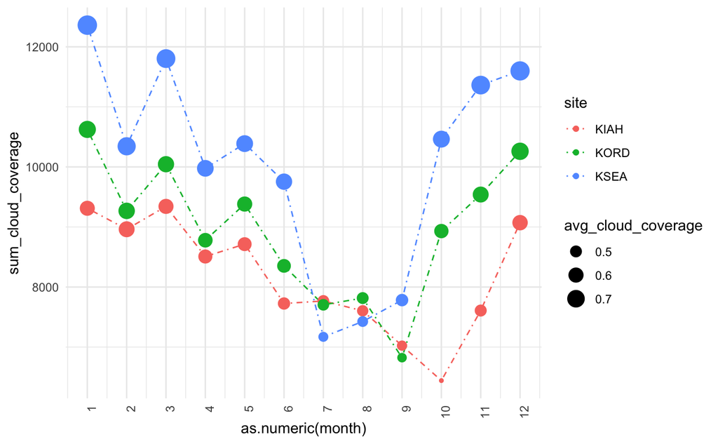

```r
houston_weather_hourly %>%
  bind_rows(., chicago_weather_hourly,seattle_weather_hourly ) %>%
  mutate(date=as.Date(date,format='%m/%d/%Y')) %>%
  separate(date,c("year","month","day")) %>%
  group_by(site, month) %>%
  summarise(sum_cloud_coverage = sum(`cld_frac`),avg_cloud_coverage = mean(`cld_frac`)) %>%
  ungroup() %>%
  ggplot(.,aes(x = as.numeric(month), y = sum_cloud_coverage, color = site)) +
  geom_line(linetype = "dotdash") +
  geom_point(aes(inherit.aes=TRUE, size = avg_cloud_coverage)) +
  theme_minimal() +
  theme(axis.text.x = element_text(angle = 90, hjust = 1)) +
  scale_x_continuous(breaks = scales::pretty_breaks(n = 10))
```

# 6 Days with less than 30% average cloud coverage

```
Ignoring unknown aesthetics: inherit.aes
```

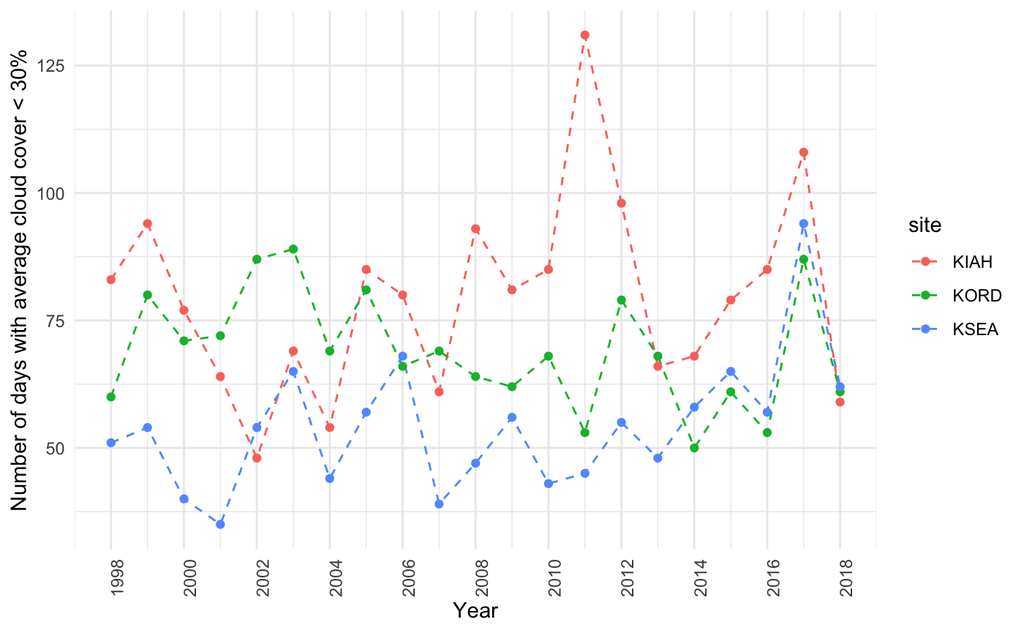

```r
houston_weather_hourly %>%
  bind_rows(., chicago_weather_hourly,seattle_weather_hourly ) %>%
  mutate(date=as.Date(date,format='%m/%d/%Y')) %>%
  separate(date,c("year","month","day")) %>%
  group_by(site, year, month, day) %>%
  summarise(avg_cloud_coverage = mean(`cld_frac`)) %>%
  ungroup() %>%
  group_by(site, year) %>%
  summarise(no_cloudy_days = sum(avg_cloud_coverage < .30)) %>%
  ggplot(.,aes(x = as.numeric(year), y = no_cloudy_days, color = site)) +
  geom_line(linetype=2) +
  geom_point(aes(inherit.aes=TRUE)) +
  theme_minimal() +
  theme(axis.text.x = element_text(angle = 90, hjust = 1)) +
  scale_x_continuous(breaks = scales::pretty_breaks(n = 10)) +
  ylab("Number of days with average cloud cover < 30%") +
  xlab("Year")
```

## 6.1 Is Chicago the windiest city in our set?

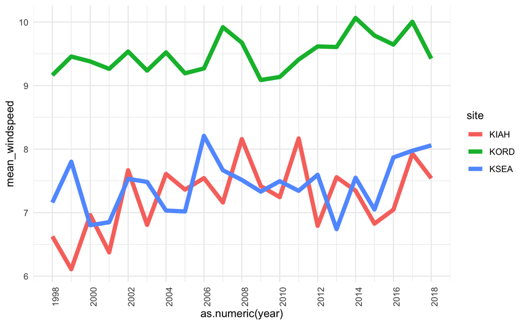

```r
houston_weather_hourly %>%
  bind_rows(., chicago_weather_hourly,seattle_weather_hourly) %>%
  mutate(date=as.Date(date,format = '%m/%d/%Y')) %>%
  separate(date,c("year","month","day")) %>%
  group_by(site, year) %>%
  summarise(mean_windspeed = mean(`windspeed`)) %>%
  ungroup() %>%
  ggplot(.,aes(x = as.numeric(year), y = mean_windspeed, color = site)) +
  geom_line(size = 2) +
  theme_minimal() +
  theme(axis.text.x = element_text(angle = 90, hjust = 1)) +
  scale_x_continuous(breaks = scales::pretty_breaks(n = 10))
```